# Linear Regression with Categorical Data

Siegfred Codia

2022-12-05

# Linear Regression with Categorical Data

To keep it simple, we start with a binary categorical data or qualitative variable.

A **dummy variable** is a binary variable that takes values of 0 or 1. This is added to a regression model to represent factors which are binary of nature, i.e. they are either observed or not observed.

Some of the use cases are the following

- Yes/No response
- Categorical Value (e.g. Male vs Female)
- Treatment Effects (control group vs treatment group)

The linear equation can be written as the following:

$$Y_i = \beta_0 + \beta_1X_i +\beta_2\delta_i + \varepsilon_i$$

where

- $X_i$ is a continuous variable
- $\delta_i = \begin{cases} 1 & i^{th} \text{ element has the quality observed} \\ 0 & \text{otherwise} \end{cases}$
- $\beta_2 :=$ effect of the dummy variable if the specified quality is possessed by element $i$

For our example, we want to find an equation that describes the salary of employees in Company ABC given their age and sex.

## Introducing the Data

We use a sample simulated dataset that includes sex and age explanatory variables of salary. Salary is in thousand pesos, per month. The process of simulation can be found in my github.

```r
source("salary_data.R")
head(salary_data)
```

```
##   age  sex salary age_20
## 1  41 male     57     21
## 2  49 male     85     29
## 3  37 male     49     17
## 4  54 male    110     34
## 5  53 male    105     33
## 6  57 male    124     37
```

## Exploratory Data Analysis

We can find a linear trend in monthly salary given the age of the employee. Logically, as one progresses in age and in their career, the salary increases. This is across all departments, so the variation is wide, and outliers may exist.

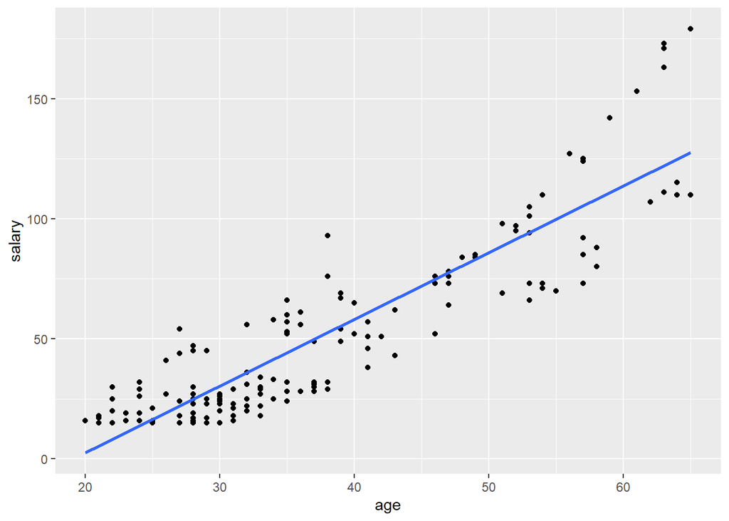

```r
ggplot(salary_data, aes(x = age, y = salary))+ geom_point() +
    geom_smooth(method = "lm", se = F)
```

**Question**: aside from age, does the sex of the employee also affect their chance of having a higher salary?

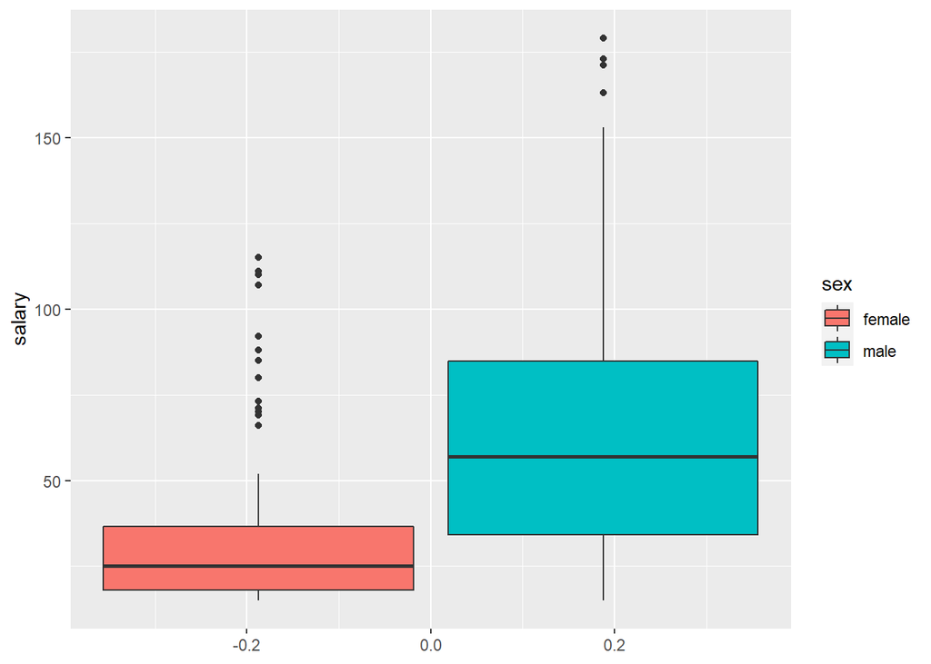

[figure not shown]

```r
ggplot(salary_data, aes(y = salary, fill = sex))+
    geom_boxplot()
```

From the above plots, we can **hypothesize that male employees may have higher salary** than female employees, i.e. Company ABC have a gender bias.

## Fitting the Model

For context on age, we first perform a simple linear regression with the following results:

```r
lm(salary ~ age, data = salary_data)%>%summary()
```

```
##
## Call:
## lm(formula = salary ~ age, data = salary_data)
##
## Residuals:
##     Min      1Q  Median      3Q     Max
## -32.363 -12.453  -1.648  10.500  51.395
##
## Coefficients:
##             Estimate Std. Error t value Pr(>|t|)
## (Intercept) -53.1119     4.5132  -11.77   <2e-16 ***
## age           2.7803     0.1133   24.55   <2e-16 ***
## ---
## Signif. codes:  0 '***' 0.001 '**' 0.01 '*' 0.05 '.' 0.1 ' ' 1
##
## Residual standard error: 17.32 on 148 degrees of freedom
## Multiple R-squared:  0.8028, Adjusted R-squared:  0.8015
## F-statistic: 602.5 on 1 and 148 DF,  p-value: < 2.2e-16
```

We also perform an ANOVA to see if there is a significant difference in salary of male and female employees.

```r
aov1 <- lm(salary ~ sex, data = salary_data)
summary(aov1)
```

```
##
## Call:
## lm(formula = salary ~ sex, data = salary_data)
##
## Residuals:
##    Min     1Q Median     3Q    Max
## -52.69 -20.91 -11.30  13.90 111.31
##
## Coefficients:
##             Estimate Std. Error t value Pr(>|t|)
## (Intercept)   36.908      4.105   8.992 1.07e-15 ***
## sexmale       30.781      5.844   5.267 4.79e-07 ***
## ---
## Signif. codes:  0 '***' 0.001 '**' 0.01 '*' 0.05 '.' 0.1 ' ' 1
##
## Residual standard error: 35.78 on 148 degrees of freedom
## Multiple R-squared:  0.1579, Adjusted R-squared:  0.1522
## F-statistic: 27.74 on 1 and 148 DF,  p-value: 4.794e-07
```

We fit the following linear equation using the `lm` function:

$$salary = \beta_0 + \beta_1age +\beta_2\delta_{sex} +\varepsilon$$

```r
mod <- lm(salary ~ age + sex, data = salary_data)
summary(mod)
```

```
##
## Call:
## lm(formula = salary ~ age + sex, data = salary_data)
##
## Residuals:
##     Min      1Q  Median      3Q     Max
## -28.130  -9.728  -1.163   7.942  44.635
##
## Coefficients:
##              Estimate Std. Error t value Pr(>|t|)
## (Intercept) -58.22335    3.73170 -15.602  < 2e-16 ***
## age           2.65126    0.09367  28.305  < 2e-16 ***
## sexmale      20.25641    2.33853   8.662 7.66e-15 ***
## ---
## Signif. codes:  0 '***' 0.001 '**' 0.01 '*' 0.05 '.' 0.1 ' ' 1
##
## Residual standard error: 14.14 on 147 degrees of freedom
## Multiple R-squared:  0.8694, Adjusted R-squared:  0.8677
## F-statistic: 489.5 on 2 and 147 DF,  p-value: < 2.2e-16
```

Note that the Adjusted R-squared increased to 86% compared to the simple linear regression. This implies that the variable `sex` contributed to the variation of `salary`, compared against when `age` was the only included predictor in the model.

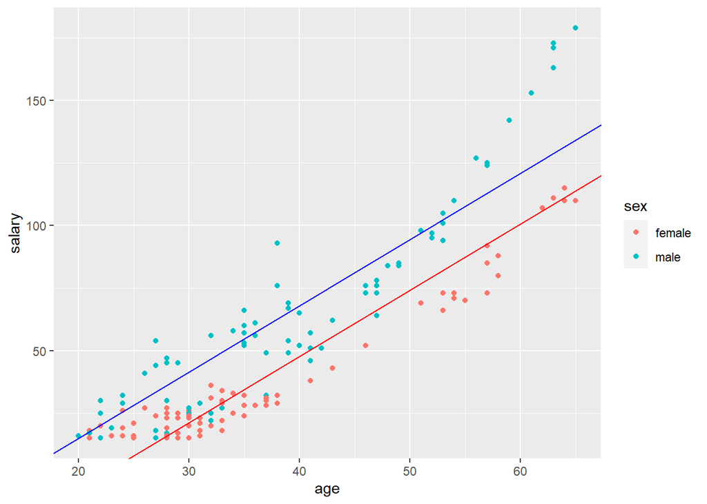

```r
ggplot(data = salary_data, aes(x = age, y = salary))+
    geom_point(aes(color = sex))+
    geom_abline(intercept = mod$coefficients[1],
                slope = mod$coefficients[2],
                color = "red")+
    geom_abline(intercept = mod$coefficients[1]+mod$coefficients[3],
                slope = mod$coefficients[2],
                color = "blue")
```

## Diagnostic Checks

```r
salary_data$resid <- resid(mod)
mean(salary_data$resid)
```

```
## [1] -2.683039e-16
```

```r
sd(salary_data$resid)
```

```
## [1] 14.04186
```

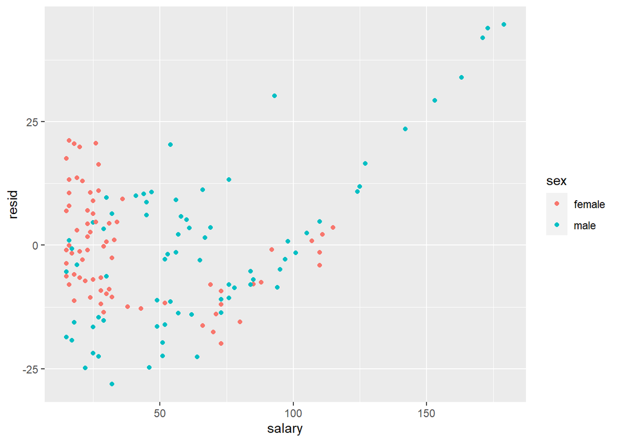

```r
ggplot(salary_data, aes(x = salary, y = resid, color = sex))+
    geom_point()
```

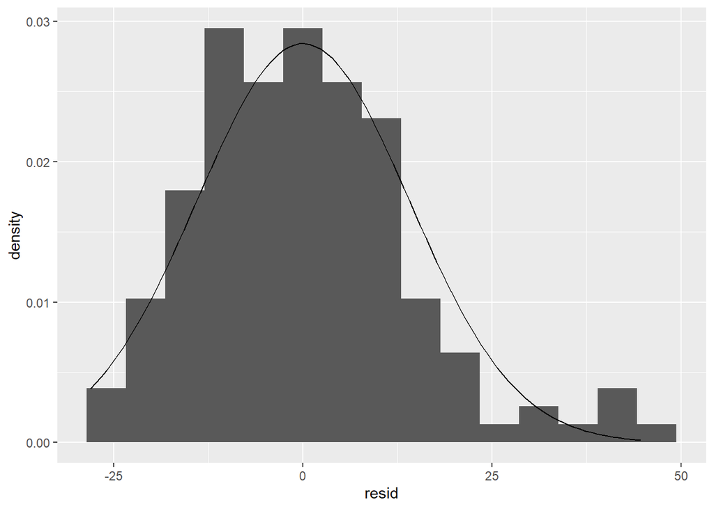

```r
ggplot(salary_data, aes(x = resid))+
    geom_histogram(aes(y = ..density..), bins = 15)+
    stat_function(fun = dnorm,
                  args = list(mean = mean(salary_data$resid),
                              sd = sd(salary_data$resid)))
```

```r
shapiro.test(salary_data$resid)
```

```
##
##  Shapiro-Wilk normality test
##
## data:  salary_data$resid
## W = 0.95916, p-value = 0.0002054
```

Remember that one of assumptions of regression analysis is that the error term or residual should follow a normal distribution. We perform a Shapiro-Wilk test with a null hypothesis that the residual follows a normal distribution. At $p < 0.05$, there is sufficient evidence to conclude that residual deviates from normality.

From this, we can explore other possible models, such as including interaction effects.

# Interaction Effects

- There are times that the effect on a response variable is based on the interaction of two independent variables.
- In the linear model without interaction effects, it is assumed that the slope of the equation is the same regardless of the value of the dummy variable; only the intercept changes, with the following case: $intercept = \begin{cases} \beta_0+\beta_2 & \delta = 1 \\ \beta_0 & \delta =0 \end{cases}$

We introduce in our model an interaction term that quantifies the slope of the model at different values of the categorical variable.

$$Y_i = \beta_0+\beta_1X_i + \beta_2\delta_i + \beta_3X_i\delta_i
+\varepsilon_i$$

In this model, we assume that if the value of our dummy variable $\delta_i$ changes, the slope of the equation also varies. To summarize, the following is the slope of our model:

$$slope = \begin{cases} \beta_1+\beta_3 & \delta = 1 \\ \beta_1 &
\delta =0 \end{cases}$$

For our example, we want to answer the following specific questions:

1. Do the employees have the same starting salaries whether they are male or female?
2. Is the salary gap between two sexes the same across all ages? Is there a favored sex in terms of promotion opportunities?

## Model 2

We need to transform first the `age` variable to calibrate the age range for easier interpretation, especially for the intercept, that the starting salary is received at age of 20.

Recall our model:

$$Y_i = \beta_0+\beta_1X_i + \beta_2\delta_i + \beta_3X_i\delta_i
+\varepsilon_i$$

where

- $Y_i$ := `salary`
- $\beta_0$ := `intercept`; starting salary of employee if not male, i.e. $(\delta=0)$, and if age = 20, i.e. $(X_i=0)$ .
- $\beta_1$ := coefficient of `age_20`; effect of age on salary if employee is not male, i.e. $\delta=0$
- $\beta_2$ := coefficient of `sexmale`; difference of starting salary of male against a female employee, i.e. intercept if $\delta=1$
  - $\beta_0+\beta_2$ is the starting salary of male employees. If $\beta_2$ is not significant, then male and female have same starting salary of $\beta_0$
- $\beta_3$ := coefficient of interaction `age_20:sexmale`; additional effect of age on salary if employee is male, i.e. $\delta=1$
  - $\beta_1+\beta_3$ is the salary increment of male employees. If $\beta_3$ is not significant, then the effect of age on salary is same for male and female.

```r
mod2 <- lm(salary ~ age_20 + sex + age_20:sex, data = salary_data)
summary(mod2)
```

```
##
## Call:
## lm(formula = salary ~ age_20 + sex + age_20:sex, data = salary_data)
##
## Residuals:
##      Min       1Q   Median       3Q      Max
## -26.7009  -9.2622  -0.2695   8.8417  31.2704
##
## Coefficients:
##                Estimate Std. Error t value Pr(>|t|)
## (Intercept)      2.9964     2.3094   1.298    0.196
## age_20           2.1353     0.1142  18.705  < 2e-16 ***
## sexmale          0.7906     3.6174   0.219    0.827
## age_20:sexmale   1.0838     0.1654   6.551 9.17e-10 ***
## ---
## Signif. codes:  0 '***' 0.001 '**' 0.01 '*' 0.05 '.' 0.1 ' ' 1
##
## Residual standard error: 12.47 on 146 degrees of freedom
## Multiple R-squared:  0.8991, Adjusted R-squared:  0.897
## F-statistic: 433.6 on 3 and 146 DF,  p-value: < 2.2e-16
```

In this model:

- the coefficient of `sexmale` is not significant, which means that the starting salary for male and female employees are not significantly different, but;
- the salary increment of female employees (coeffcient of `age_20`), and the additional salary increment of male employees (coefficient of `age_20:sexmale` ) are significant, which implies that the age contributes positively for both sexes, with an additional incentive for male employees.

## Model 3

Since one coefficient is not significant, we regress again for another model, removing the `sexmale` term in the equation:

$$Y_i = \beta_0+\beta_1X_i +\beta_3X_i\delta_i +\varepsilon_i$$

```r
mod3 <- lm(salary ~ age_20 + age_20:sex, data = salary_data)
summary(mod3)
```

```
##
## Call:
## lm(formula = salary ~ age_20 + age_20:sex, data = salary_data)
##
## Residuals:
##      Min       1Q   Median       3Q      Max
## -26.6969  -9.3217  -0.2472   9.0651  31.4292
##
## Coefficients:
##                Estimate Std. Error t value Pr(>|t|)
## (Intercept)     3.31866    1.77175   1.873    0.063 .
## age_20          2.12277    0.09846  21.559   <2e-16 ***
## age_20:sexmale  1.11347    0.09404  11.840   <2e-16 ***
## ---
## Signif. codes:  0 '***' 0.001 '**' 0.01 '*' 0.05 '.' 0.1 ' ' 1
##
## Residual standard error: 12.43 on 147 degrees of freedom
## Multiple R-squared:  0.8991, Adjusted R-squared:  0.8977
## F-statistic: 654.7 on 2 and 147 DF,  p-value: < 2.2e-16
```

The following is the visualization of the linear model with an interaction effect included:

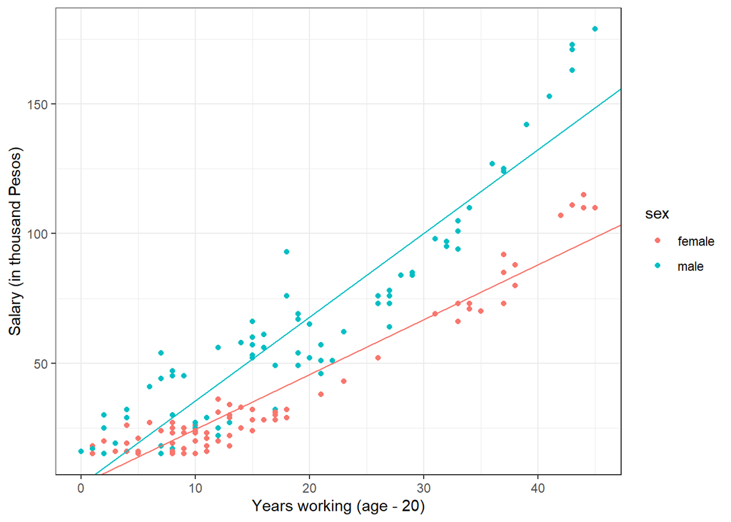

```r
ggplot(data = salary_data, aes(x = age_20, y = salary))+theme_bw()+
    geom_point(aes(color = sex))+
    geom_abline(intercept = mod3$coefficients[1],
                slope = mod3$coefficients[2],
                color = "#F8766D")+
    geom_abline(intercept = mod3$coefficients[1],
                slope = mod3$coefficients[2] +
                    mod3$coefficients[3],
                color = "#00BFC4")+
    xlab("Years working (age - 20)")+
    ylab("Salary (in thousand Pesos)")
```

### Diagnostics for model 3

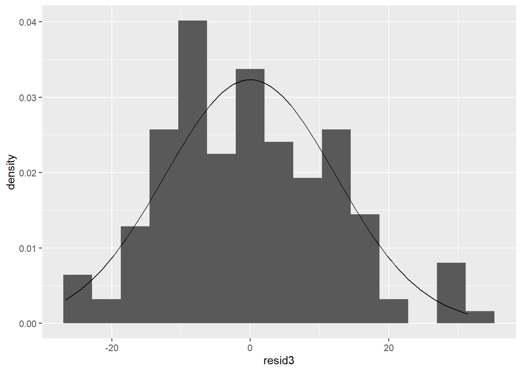

```r
salary_data$resid3 <- resid(mod3)
ggplot(salary_data, aes(x = resid3))+
    geom_histogram(aes(y = ..density..), bins = 15)+
    stat_function(fun = dnorm,
                  args = list(mean = mean(salary_data$resid3),
                              sd = sd(salary_data$resid3)))
```

```r
shapiro.test(salary_data$resid3)
```

```
##
##  Shapiro-Wilk normality test
##
## data:  salary_data$resid3
## W = 0.98051, p-value = 0.03174
```

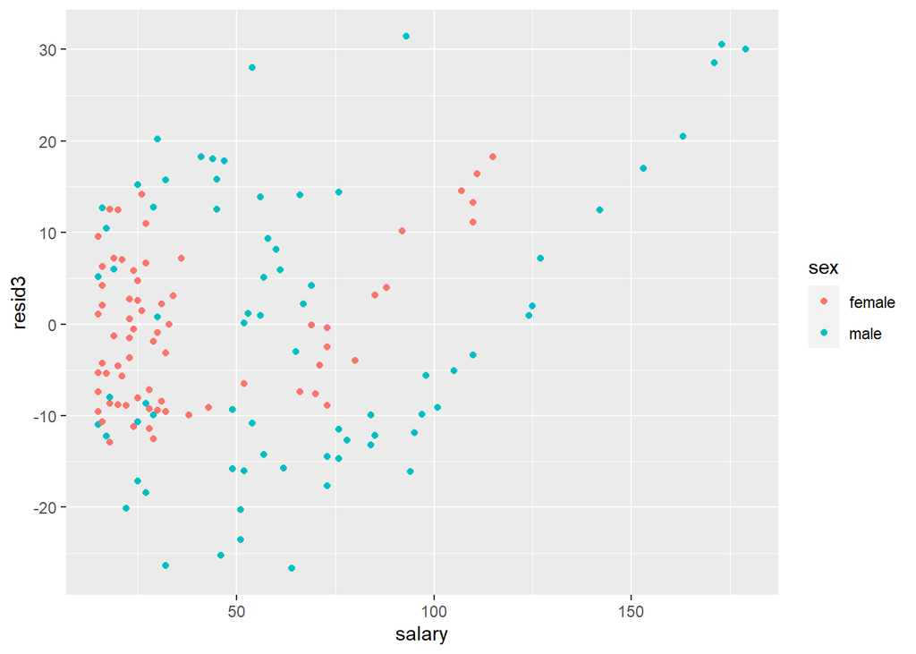

```r
ggplot(salary_data, aes(x = salary, y = resid3, color = sex))+
    geom_point()
```

For future studies, it is recommended to consider non-linear equations, such as using square or logarithmic transformations on some variables. Logically, the amount of salary increase an employee gets is based on the percentage of their current salary, indicating a possible exponential trend of salary given age.